# GLM-Binomial

## Deviance

The (residual) deviance in the context of GLM can be considered as the distance between the current model and a perfect model (often called *saturated model*).

$$D_{res} = -2[\log(\mathcal{L}_{current}) - (\log\mathcal{L}_{sat})]$$

Where $\mathcal{L}$ is the likelihood of the considered model (see the previous slides). Clearly, the lower the deviance, the closer the current model to the perfect model suggesting a good fit.

## Deviance - Saturated model

The saturated model is a model where each observation $x_i$ has a parameter.

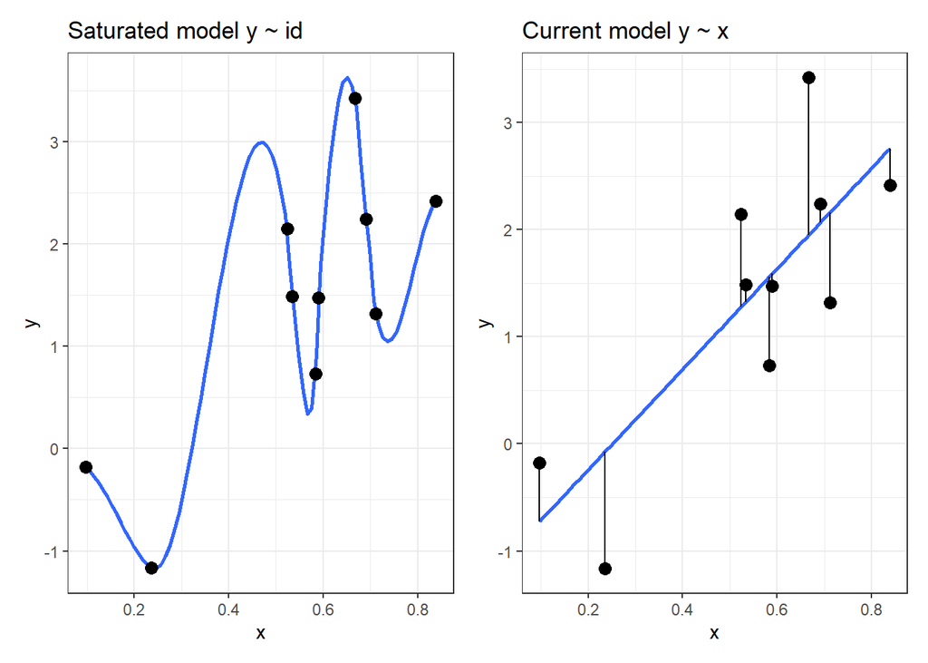

## Deviance - Null model

Another important quantity is the *null deviance* that is expressed as the distance between the *null model* and the *saturated model*.

$$D_{null} = -2[\log(\mathcal{L}_{null}) - (\log\mathcal{L}_{sat})]$$

The *null deviance* can be interpreted as the maximal deviance because is estimated using a model without predictors. A good model will have a residual deviance lower than the null model.

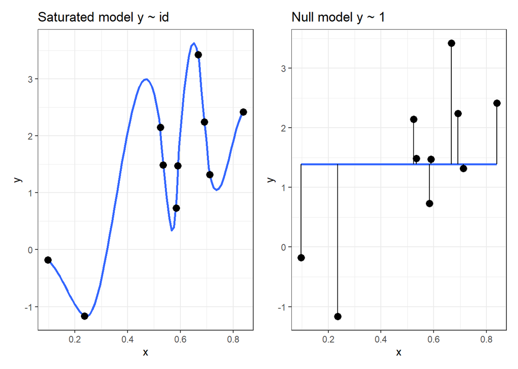

## Deviance - Likelihood Ratio Test

When we perform a likelihood ratio test (see previous slides) we are essentially comparing the residual deviance (or the likelihood) of two models.

```r
fit_null <- glm(y ~ 1, data = dat, family = binomial(link = "logit"))
fit_current <- glm(y ~ x, data = dat, family = binomial(link = "logit"))
```

With the null model clearly the residual deviance is the same as the null deviance because we are not using predictors to reduce the deviance.

```r
summary(fit_null)
```

```
##
## Call:
## glm(formula = y ~ 1, family = binomial(link = "logit"), data = dat)
##
## Coefficients:
##             Estimate Std. Error z value Pr(>|z|)
## (Intercept)  -0.3228     0.2865  -1.126     0.26
##
## (Dispersion parameter for binomial family taken to be 1)
##
##     Null deviance: 68.029  on 49  degrees of freedom
## Residual deviance: 68.029  on 49  degrees of freedom
## AIC: 70.029
##
## Number of Fisher Scoring iterations: 4
```

If the predictor `x` is useful in explaining `y` the residual deviance will be reduced compared to the null (overall deviance).

```r
summary(fit_current)
```

```
##
## Call:
## glm(formula = y ~ x, family = binomial(link = "logit"), data = dat)
##
## Coefficients:
##             Estimate Std. Error z value Pr(>|z|)
## (Intercept)   -5.045      1.470  -3.432 0.000599 ***
## x              9.535      2.659   3.586 0.000336 ***
## ---
## Signif. codes:  0 '***' 0.001 '**' 0.01 '*' 0.05 '.' 0.1 ' ' 1
##
## (Dispersion parameter for binomial family taken to be 1)
##
##     Null deviance: 68.029  on 49  degrees of freedom
## Residual deviance: 36.745  on 48  degrees of freedom
## AIC: 40.745
##
## Number of Fisher Scoring iterations: 6
```

Comparing the two models we can understand if the deviance reduction can be considered statistically significant.

```r
anova(fit_null, fit_current, test = "LRT")
```

```
## Analysis of Deviance Table
##
## Model 1: y ~ 1
## Model 2: y ~ x
##   Resid. Df Resid. Dev Df Deviance  Pr(>Chi)
## 1        49     68.029
## 2        48     36.745  1   31.284 2.229e-08 ***
## ---
## Signif. codes:  0 '***' 0.001 '**' 0.01 '*' 0.05 '.' 0.1 ' ' 1
```

Notice that the difference between the two residual deviances is the test statistics that is distributed as a $\chi^2$ with $df = 1$.

[figure not shown]

## Deviance[^3]

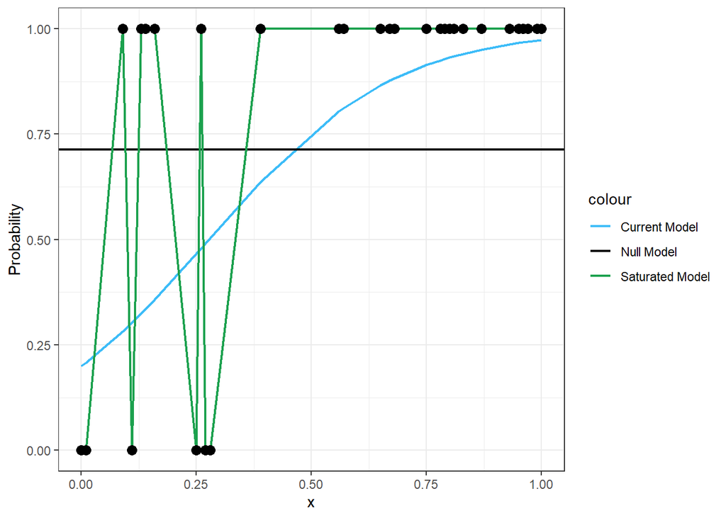

## Deviance - Example

Let’s fit the three models:

```r
# null
fit0 <- glm(exam ~ 1, data = dat, family = binomial(link = "logit"))
# current
fit <- glm(exam ~ tv_shows, data = dat, family = binomial(link = "logit"))
# saturated
fits <- glm(exam ~ 0 + id, data = dat, family = binomial(link = "logit"))
```

We can calculate the residual deviance:

```r
-2*(logLik(fit) - logLik(fits))
```

```
## 'log Lik.' 126.3001 (df=2)
```

```r
deviance(fit)
```

```
## [1] 126.3001
```

We can calculate the null deviance:

```r
-2*(logLik(fit0) - logLik(fits))
```

```
## 'log Lik.' 130.6836 (df=1)
```

```r
deviance(fit0)
```

```
## [1] 130.6836
```

## $R^2$

Compared to the standard linear regression, there are multiple ways to calculate an $R^2$ like measure for GLMs and there is no consensus about the most appropriate method. There are some useful resources:

- https://stats.oarc.ucla.edu/other/mult-pkg/faq/general/faq-what-are-pseudo-r-squareds/

To note, some measures are specific for the binomial GLM while other measures can be applied also to other GLMs (e.g., the poisson)

We will se:

- McFadden’s pseudo-$R^2$ (for GLMs in general)
- Tjur’s $R^2$ (only for binomial/binary models)

## McFadden’s pseudo-$R^2$

The McFadden’s pseudo-$R^2$ compute the ratio between the log-likelihood of the intercept-only (i.e., null) model and the current model[@McFadden1987-qq]:

$$R^2 = 1 - \frac{\log(\mathcal{L_{current}})}{\log(\mathcal{L_{null}})}$$

There is also the adjusted version that take into account the number of parameters of the model. In R can be computed manually or using the `performance::r2_mcfadden()`:

```r
performance::r2_mcfadden(fit)
```

```
## # R2 for Generalized Linear Regression
##        R2: 0.034
##   adj. R2: 0.018
```

## Tjur’s $R^2$

This measure is the easiest to interpret and calculate but can only be applied for binomial binary models [@Tjur2009-ml]. Is the absolute value of the difference between the proportions of correctly classifying $y = 1$ and $y = 0$ from the model:

$$\begin{align*}
p_1 = p(y_i = 1 |\hat y_i = 1) \\
p_2 = p(y_i = 0 |\hat y_i = 0) \\
R^2 = |p_1 - p_2|
\end{align*}$$

```r
performance::r2_tjur(fit2)
```

```
## Tjur's R2
## 0.5259333
```

## Residuals

The main problem of GLM is that the mean and the variance are linked. For example, the mean of a binomial distribution is $np$ and the variance is $np(1-p)$. In the standard linear model we have two parameters, $\mu$ and the residual $\sigma$ that are independent.

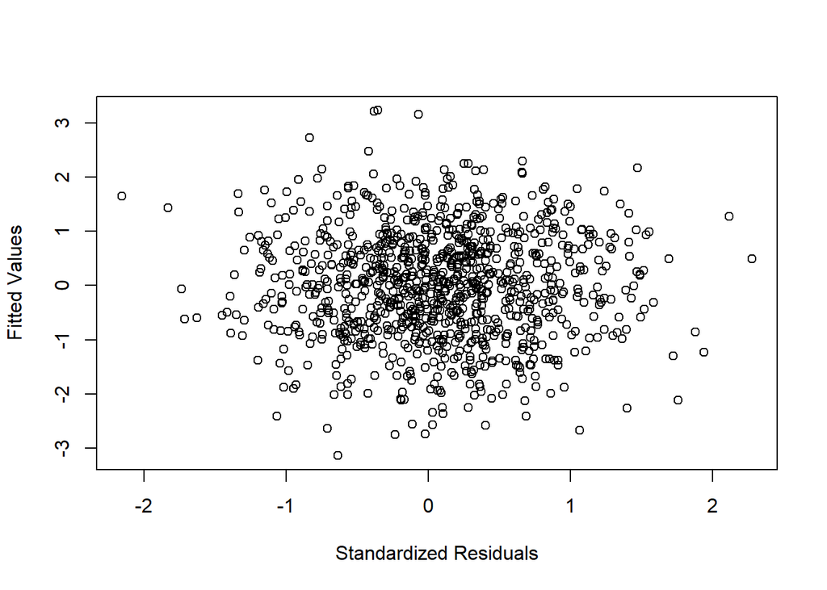

```r
x <- rnorm(1000)
y <- 0.1 + 0.6 * x + rnorm(1000)
fit <- lm(y ~ x)
ri_lm <- residuals(fit) / sigma(fit)
plot(fitted(fit), ri_lm,
     ylab = "Fitted Values",
     xlab = "Standardized Residuals")
```

When using a linear model (thus assuming a constant $\sigma$ and independence between mean and variance) the residuals pattern is very different:

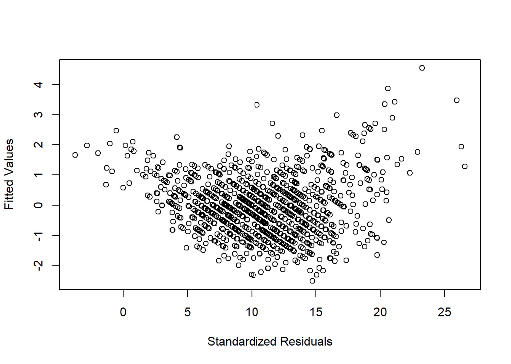

```r
x <- rnorm(1000)
y <- rpois(1000, exp(log(10) + log(1.5) * x))
fit_poi <- lm(y ~ x)

plot(fitted(fit_poi), rstandard(fit_poi),
     xlab = "Standardized Residuals",
     ylab = "Fitted Values")
```

As for standard linear models there are different types of residuals:

- raw (response) residuals
- pearson residuals
- deviance residuals
- standardized residuals

## Raw Residuals

Raw residuals, also called response residuals are the simplest type of residuals. They are calculated as in standard regression as:

$$\begin{align*}
r_i = y_i - \hat y_i
\end{align*}$$

Where $\hat y_i$ are the fitted values where the inverse of the link function has been applied.

In R:

```r
# equivalent to residuals(fit, type = "response")
ri <- fit$y - fitted(fit)
ri[1:5]
```

```
##          1          2          3          4          5
## 0.56826521 0.18039223 0.07097155 0.56848124 0.04399144
```

The problem is that in GLMs the mean and the variance of the distribution are not independent, creating problems in residual analysis.

We can use the function `car::residualPlot()` to plot different type of residuals against fitted values:

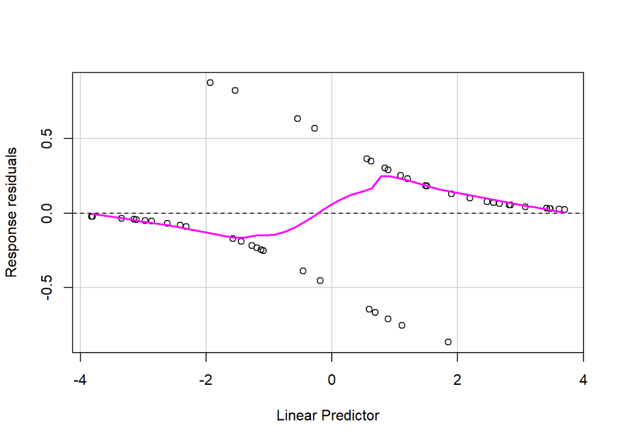

```r
car::residualPlot(fit, type = "response")
```

## Why raw residuals are problematic?

This plot[^4] shows an example with the same residual for two different $x$ values on a Poisson GLM. Beyond the model itself, the same residual can be considered as extreme for low $x$ values and plausible for high $x$ values:

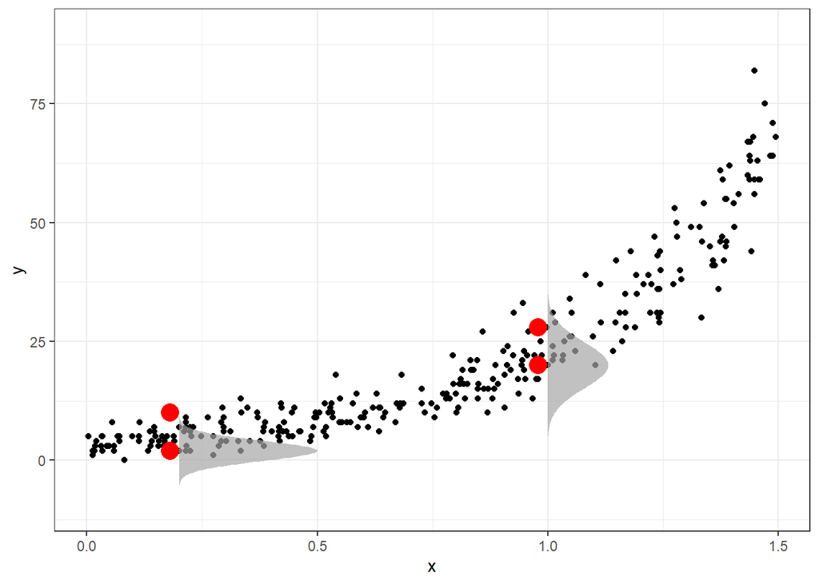

## Binned (raw) Residuals

Gelman and colleagues [@Gelman2020-tg, @Gelman2006-pc] proposed a type of residuals called **binned residuals** to solve the problem of the previous plot for Binomial GLMs:

- divide the fitted values into $n$ bins. The number is arbitrary but we need each bin to have enough observation to compute a reliable average
- calculate the average fitted value and residual for each bin
- for each bin we can compute the standard error as $SE = \frac{p_j (1 - p_j)}{n_j}$ where $p_j$ is the average fitted probability and $n_j$ is the number of observation in the bin $j$
- Then we can plot each bin and the confidence intervals (e.g., as $\pm 2*SE$) where ~95% of binned residuals should be within the CI if the model is true

We can use the `arm::binnedplot()` function to automatically create and plot the binned residuals:

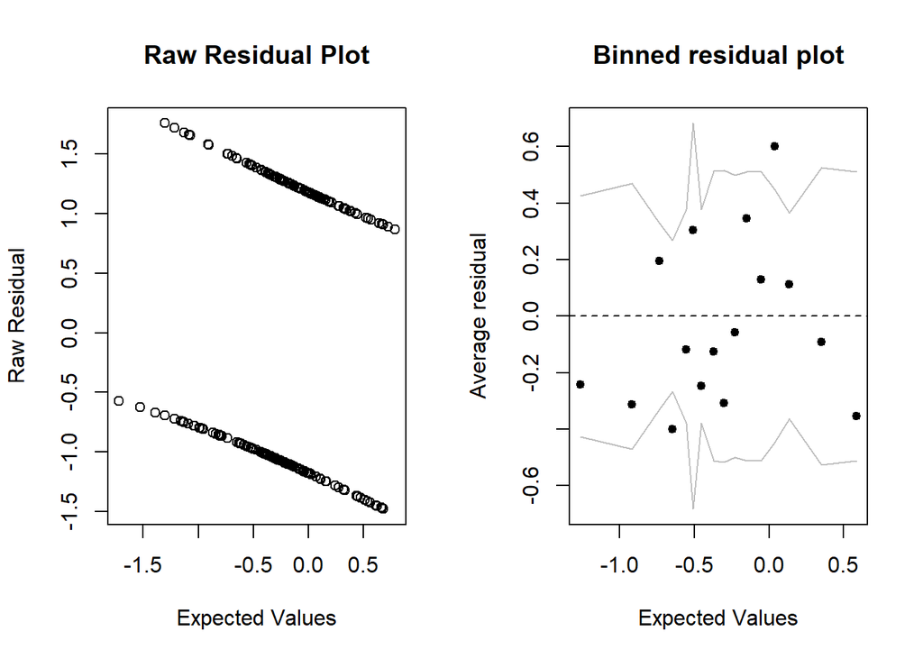

```r
par(mfrow = c(1,2))
plot(x, y, xlab = "Expected Values", ylab = "Raw Residual", main = "Raw Residual Plot")
binnedplot(x,y)
```

## Pearson residuals

Pearson residuals are raw residuals divided by the standard deviation of each residual. Given that the mean-variance relationship of GLMs, dividing by the standard deviation partially solve the mean-variance relationship. The denominator can be calculated just using the appropriate variance formula for that specific GLM.

$$r_i = \frac{y_i - \hat y_i}{\sqrt{V(\hat y_i)}}$$

## Pearson vs Raw residuals

We can see the difference for a Poisson model[^5] when using raw vs pearson residuals. The non-constant variance is controlled on the right.

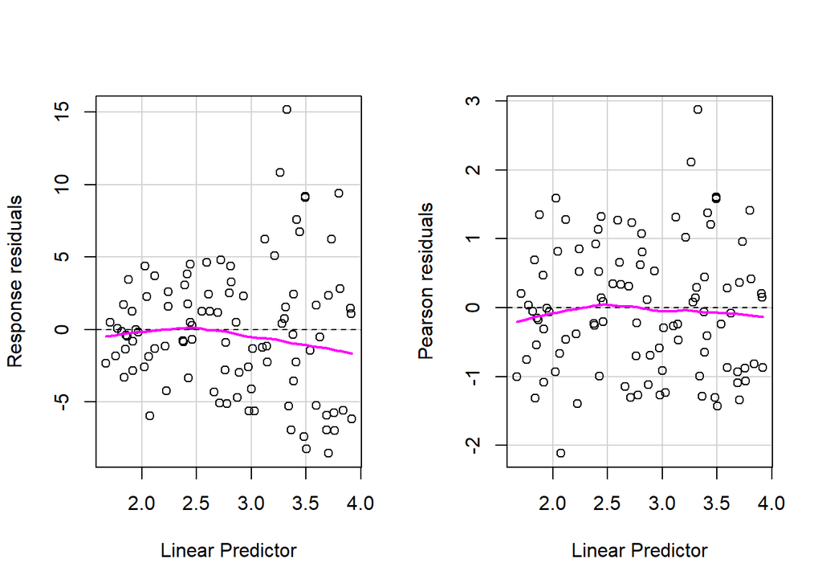

$$r_i = \frac{y_i - \hat y_i}{\sqrt{\hat y_i(1 - \hat y_i)}}$$

```r
# equivalent to residuals(fit, type = "pearson")
yi <- fitted(fit)
ri_pearson <- ri / sqrt(yi * (1 - yi))
ri_pearson[1:5]
```

```
##          1          2          3          4          5
## 1.17341398 0.42948479 0.14213499 1.21450070 0.09047435
```

## Deviance residuals

Deviance residuals are based on the residual deviance that we defined before. In fact, the residual deviance was just the sum of squared deviance residuals.

$$r_i = sign(y_i - \hat y_i) \sqrt{-2[\log \mathcal{L}y_{i_{current}} -
\log \mathcal{L}y_{i_{saturated}}]}$$
Where $sign$ is the sign of the raw residual $i$. For the Bernoulli model the $\log \mathcal{L}y_{i_{saturated}}$ is always 0.

## Deviance Residuals

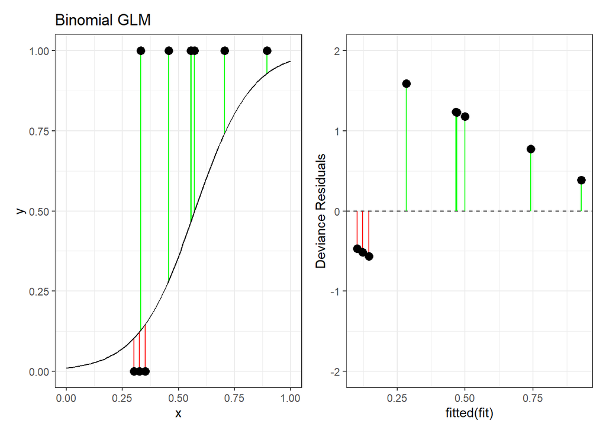

To calculate and demonstrate manually the deviance residuals we can compute them manually in R:

```r
# residual(fit, type = "deviance")
yhat <- fitted(fit) # fitted
y <- fit$y # actual values

# the likelihood is dbinom
ri_dev <- sign(y - yhat) * sqrt(-2*(log(dbinom(y, 1, yhat)) - log(dbinom(y, 1, y))))
```

```r
# notice that the log lik of the saturated model log(dbinom(y, 1, y)) is 0
log(dbinom(y, 1, y))
```

```
##  1  2  3  4  5  6  7  8  9 10 11 12 13 14 15 16 17 18 19 20 21 22 23 24 25 26
##  0  0  0  0  0  0  0  0  0  0  0  0  0  0  0  0  0  0  0  0  0  0  0  0  0  0
## 27 28 29 30 31 32 33 34 35 36 37 38 39 40 41 42 43 44 45 46 47 48 49 50
##  0  0  0  0  0  0  0  0  0  0  0  0  0  0  0  0  0  0  0  0  0  0  0  0
```

```r
ri_dev[1:5]
```

```
##          1          2          3          4          5
## -0.2370588  0.3033530 -1.0310244  0.2331303 -0.8429485
```

```r
residuals(fit, type = "deviance")[1:5]
```

```
##          1          2          3          4          5
## -0.2370588  0.3033530 -1.0310244  0.2331303 -0.8429485
```

## Quick recap about hat values in linear regression

The **hat matrix** $H$ is calculated as $H = X \left(X^{\top} X \right)^{-1} X^{\top}$ is a $n \times n$ matrix where $n$ is the number of observations. The diagonal of the $H$ matrix contained the hat values or leverages.

The $i^{th}$ leverage score ($h_{ii}$) is interpreted as the weighted distance between $x_i$ and the mean of $x_i$’s. In practical terms is the $i^{th}$ observed value influence the $i^{th}$ fitted value. An high leverage suggest that the observation is far from the mean of predictors and have an high influence on the fitted values.

- $h_{ii}$ ranges between 0 and 1
- The sum of all $h_{ii}$ values is the number of parameters $p$
- As a rule of thumb, an observation have an high leverage if $h_{ii} > 2 \bar h$ where $\bar h$ is the average hat value

## Quick recap about hatvalues in linear regression

For a simple linear regression ($y \sim x$) the hat values are calculated as:

$$h_i = \frac{1}{n} + \frac{(X_i - \bar X)^2}{\sum^n_{j = 1}(X_i - \bar
X)^2}$$

In R the function `hatvalues()` return the diagonal of the $H$ matrix for `glm` and `lm`:

```r
hatvalues(fit)[1:10]
```

```
##          1          2          3          4          5          6          7
## 0.02874015 0.03492581 0.03968557 0.02782301 0.04357230 0.04652508 0.04435804
##          8          9         10
## 0.04012613 0.03948651 0.04743780
```

To note, for GLM and multiple regression in general, the equation is different and more complicated but the intepretation and the R implementation is the same.

## Standardized Residuals

Both the response, pearson and deviance residuals can be considered as raw residuals. We can standardize residuals by dividing for the standard error computed with the hat values. In this way, the distribution will be approximately normal with $\mu = 0$ and $\sigma = 1$.

$$r_{s_i} = \frac{r_i}{\sqrt{(1 - \hat h_{ii})}}$$

Where $r_i$ can be raw, pearson or deviance residuals.

In R they can be extracted using `rstandard()`:

```r
rstandard(fit, type = "pearson")[1:5]
```

```
##          1          2          3          4          5
## -0.1712897  0.2208858 -0.8546823  0.1683326 -0.6678440
```

```r
rstandard(fit, type = "deviance")[1:5]
```

```
##          1          2          3          4          5
## -0.2405406  0.3087934 -1.0521126  0.2364427 -0.8619359
```

We can try to manually calculate the residuals to better understand.

```r
yhat <- fitted(fit) # fitted
yi <- fit$y # observed
hi <- hatvalues(fit) # diagonal of the hat matrix

# pearson residuals
pi <- (yi - yhat) / sqrt(yhat * (1 - yhat))

# standardized
pis <- pi / sqrt(1 - hi)
pis[1:5]
```

```
##          1          2          3          4          5
## -0.1712897  0.2208858 -0.8546823  0.1683326 -0.6678440
```

```r
rstandard(fit, type = "pearson")[1:5]
```

```
##          1          2          3          4          5
## -0.1712897  0.2208858 -0.8546823  0.1683326 -0.6678440
```

```r
# deviance (for binomial GLM the loglik of the saturated model is 0)
di <- sign(yi - yhat) * sqrt(-2*log(dbinom(y, 1, yhat)))

# standardized
dis <- di / sqrt(1 - hi)

dis[1:5]
```

```
##          1          2          3          4          5
## -0.2405406  0.3087934 -1.0521126  0.2364427 -0.8619359
```

```r
rstandard(fit, type = "deviance")[1:5]
```

```
##          1          2          3          4          5
## -0.2405406  0.3087934 -1.0521126  0.2364427 -0.8619359
```

## Quantile residuals

The **quantile residuals** is another proposal for residual analysis. The idea is to map the quantile of the cumulative density function (CDF) of the random component into the CDF of the normal distribution.

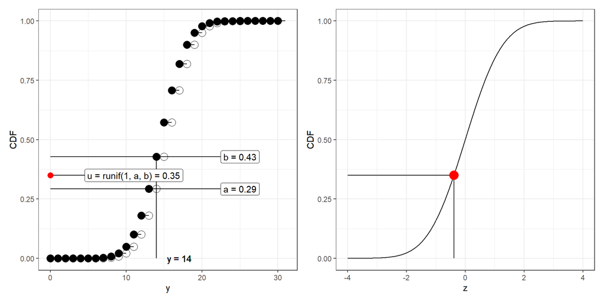

**Quantile residuals** are very useful especially for Discrete GLMs (binomial and poisson) and are exactly normally distributed (under respected model assumptions) compared to **deviance** and **pearson** residuals [@Dunn1996-yd]. They can be calculated using the `statmod::qresid(fit)` function. Authors suggest to run the function 4 times to disentagle between the randomization and the systematic component.

```r
statmod::qresid(fit)[1:5]
```

```
## [1] -0.33677932  1.04616589 -0.43878900  0.01511622 -1.07265867
```

```r
statmod::qresid(fit)[1:5] # different every time
```

```
## [1]  1.2349067 -0.6689038  0.2171433 -0.9988869 -0.4189008
```

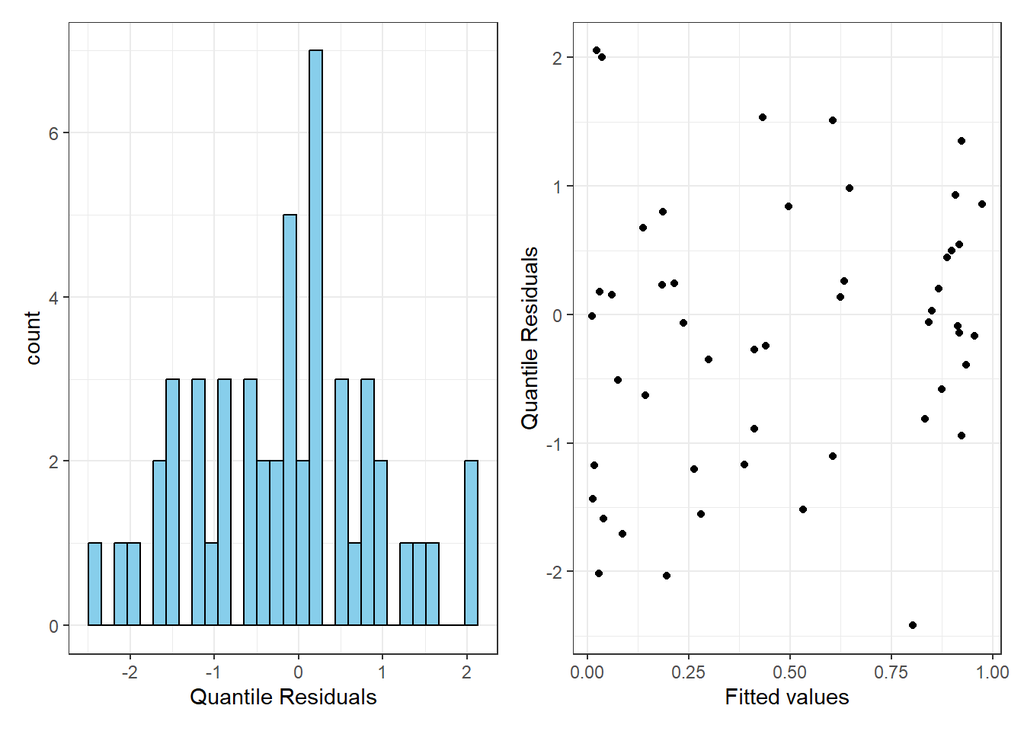

## More on residuals

Residuals for GLMs are complicated. To have a more detailed and clear overview see:

- @Agresti2015-cz, Sections 4.4.5, 4.4.6
- @Dunn2018-ww, Chapter 8

## Classification accuracy/Error rate

The **error rate** (ER) is defined as the proportion of cases for which the deterministic prediction i.e. guessing $y_i = 1$ if $logit^{-1}(\hat y_i) > 0.5$ and guessing $y_i = 0$ if $logit^{-1}(\hat y_i) > 0.5$ is wrong. Clearly, $1 - ER$ is the **classification accuracy**.

I wrote the `error_rate` function that simply compute the error rate of a given model:

```r
error_rate <- function(fit){
    pi <- predict(fit, type = "response")
    yi <- fit$y
    cr <- mean((pi > 0.5 & yi == 1) | (pi < 0.5 & yi == 0))
    1 - cr # error rate
}
```

```r
error_rate(fit)
```

```
## [1] 0.14
```

We could compare the error rate of a given model with the error rate of the null model or another similar model (with a model comparison approach):

```r
fit0 <- update(fit, . ~ -x) # removing the x predictor, now intercept only model
error_rate(fit0)
```

```
## [1] 0.48
```

```r
# the error rate of the null model is ... greater/less than the actual model
er_ratio = error_rate(fit0)/error_rate(fit)
```

The **error rate** of the null model is 3.429 times greater than the actual model.

- For a given model, the error rate should be less than $0.5$, otherwise setting all $\beta$’s to 0 (i.e., null model) would be considered a better model [@Gelman2020-tg].
- For example if the average $p$ in a dataset is $\overline p = 0.3$ means that a null model would have an error rate of $0.3$ and a classification accuracy of $1 - \overline p = 0.7$.
- When the proportion of 1s and 0s is the same, the error rate of the null model is 0.5, otherwise is the proportion of 1s
- Including predictors we aim to reduce the error rate (compared to the null model) because the ability to correctly classify an observation increase.
- The error rate can be misleading, see @Gelman2020-tg (pp. 255-256)

## Outliers and influential observations

Identification of influential observation and outliers of GLMs is very similar to standard regression models. We will briefly see:

- Cook Distances
- DFBETAs

## Cook Distances

The Cook Distance of an observation $i$ measured the impact of that observation on the overall model fit. If removing the observation $i$ has an high impact, the observation $i$ is likely an influential observation. For GLMs they are defined as:

$$\begin{align*}
D_i = \frac{r_i^2}{\phi p} \frac{h_{ii}}{1 - h_{ii}}
\end{align*}$$

Where $p$ is the number of model parameters, $r_i$ are the standardized pearson residuals (`rstandard(fit, type = "pearson")`) and $h_{ii}$ are the hatvalues (leverages). $\phi$ is the dispersion parameter of the GLM that for binomial and poisson models is fixed to 1 (see Dunn (2018, Table 5.1)) Usually an observation is considered influential if $D_i > \frac{4}{n}$ where $n$ is the sample size.

## DFBETAs

DFBETAs measure the impact of the observation $i$ on the estimated parameter $\beta_j$:

$$\begin{align*}
DFBETAS_i = \frac{\beta_j - \beta_{j(i))}}{\sigma_{\beta_{j(i)}}}
\end{align*}$$

Where $i$ denote the parameters and standard error on a model fitted without the $i$ observation[^6]. Usually an observation is considered influential if $|DFBETAs_{i}| > \frac{2}{\sqrt{n}}$ where $n$ is the sample size.

## Extracting influence measures

In R we can use the `influence.measures()` function to calculate each influence measure explained before[^7].

```r
fit <- update(fit, data = fit$model[1:50, ])
```

```r
infl <- influence.measures(fit)$infmat
head(infl)
```

```
##        dfb.1_      dfb.x       dffit    cov.r       cook.d        hat
## 1 -0.04419414 0.04109800 -0.04442749 1.070827 0.0004340963 0.02874015
## 2 -0.04672053 0.05681844  0.06310261 1.075710 0.0008828590 0.03492581
## 3 -0.11865551 0.05713533 -0.23265873 1.028011 0.0150937972 0.03968557
## 4 -0.03348170 0.03972704  0.04294688 1.069920 0.0004054759 0.02782301
## 5 -0.14588644 0.10150547 -0.19921442 1.051194 0.0101596403 0.04357230
## 6 -0.07575414 0.10700698  0.14303484 1.074641 0.0048052405 0.04652508
```

The first two columns are the DFBETAs for each parameter, the `cook.d` columns contains the Cook Distances and `hat` is the diagonal of the $H$ matrix.

## Plotting influence measures

I wrote the `cook_plot()` function to easily plot the cook distances along with the identification of influential observations:

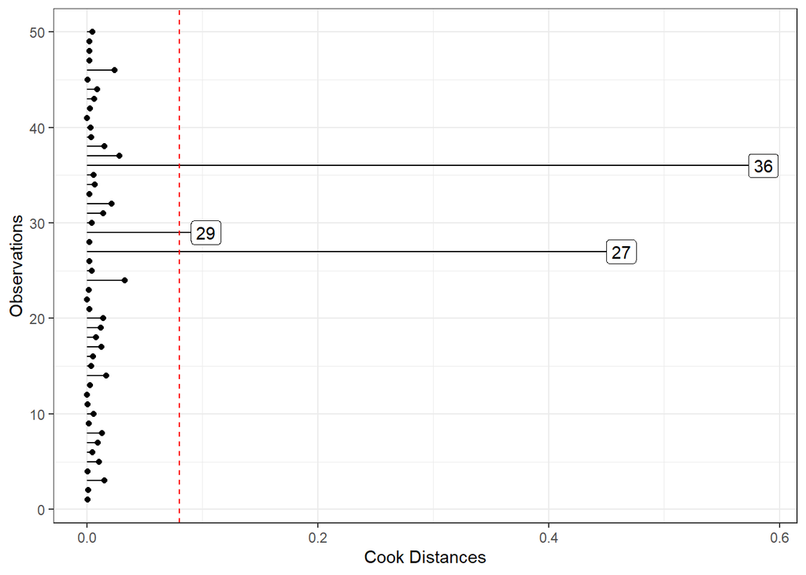

```r
cook_plot(fit)+theme_bw()
```

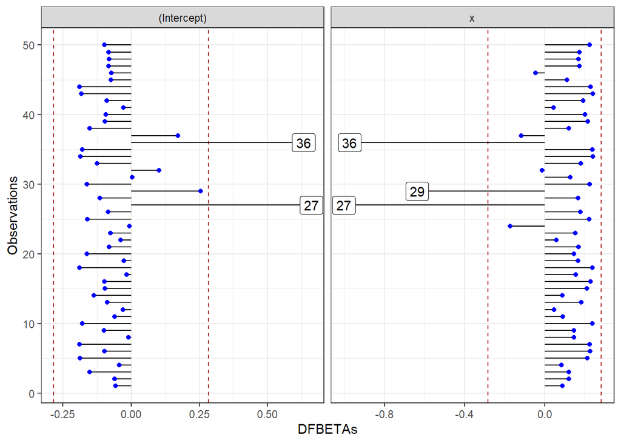

```r
dfbeta_plot(fit)+theme_bw()
```

## Binomial vs Binary

There are several practical differences between binomial and binary models:

- data structure
- fitting function in R
- residuals and residual deviance
- type of predictors

## Binomial vs Binary data structure

The most basic Binomial regression is a vector of binary $y$ values and a continuous or categorical predictor. Let’s see a common data structure in this case:

```r
n <- 30
x <- runif(n, 0, 1)
dat <- sim_design(ns = n, nx = list(x = x))
b0 <- qlogis(0.01)
b1 <- 8

dat |>
    sim_data(plogis(b0 + b1*x), "binomial") |>
    select(-lp) |>
    round(2) |>
    filor::trim_df(4)
```

```
##    id    x   y
## 1   1 0.85   1
## 2   2 0.16   0
## 3   3 0.08   0
## 4   4 0.17   0
## 5 ...  ... ...
## 6  27 0.52   1
## 7  28 0.64   1
## 8  29 0.11   0
## 9  30 0.54   1
```

Or equivalently with a categorical variable:

```r
n <- 15
x <- c("a", "b")
dat <- sim_design(n, cx = list(x = x))
b0 <- qlogis(0.4)
b1 <- log(odds_ratio(0.7, 0.4))

dat |>
    sim_data(plogis(b0 + b1*x_c), "binomial") |>
    dplyr::select(-x_c, -lp) |>
    filor::trim_df(4)
```

```
##    id   x   y
## 1   1   a   1
## 2   2   b   0
## 3   3   a   0
## 4   4   b   0
## 5 ... ... ...
## 6  27   a   0
## 7  28   b   1
## 8  29   a   0
## 9  30   b   0
```

When using a Binomial data structure we count the number of success for each level of $x$. `nc` is the number of 1 responses, `nf` is the number of 0 response out of `nt` trials:

```r
x <- seq(0, 1, 0.05)
nt <- 10
nc <- rbinom(length(x), nt, plogis(qlogis(0.01) + 8*x))
dat <- data.frame(x, nc, nf = nt - nc,  nt)

dat |>
    filor::trim_df(4)
```

```
##      x  nc  nf  nt
## 1    0   0  10  10
## 2 0.05   0  10  10
## 3  0.1   1   9  10
## 4 0.15   0  10  10
## 5  ... ... ... ...
## 6 0.85   9   1  10
## 7  0.9   8   2  10
## 8 0.95   9   1  10
## 9    1  10   0  10
```

With a categorical variable we have essentially a contingency table:

```r
x <- c("a", "b")
nt <- 10
nc <- rbinom(length(x), nt, plogis(qlogis(0.4) + log(odds_ratio(0.7, 0.4))*ifelse(x == "a", 1, 0)))

datc <- data.frame(x, nc, nf = nt - nc,  nt)
datc
```

```
##   x nc nf nt
## 1 a  5  5 10
## 2 b  4  6 10
```

## Binomial vs Binary: data structure

Clearly, expanding or aggregating data is the way to convert a binary into a binomial data structure and the opposite:

```r
# from binomial to binary
bin_to_binary(datc, nc, nt) |>
    select(y, x) |>
    filor::trim_df()
```

```
##     y   x
## 1   1   a
## 2   1   a
## 3   1   a
## 4   1   a
## 5 ... ...
## 6   0   b
## 7   0   b
## 8   0   b
## 9   0   b
```

```r
# from binary to binomial
bin_to_binary(datc, nc, nt)  |>
    binary_to_bin(y, x)
```

```
## # A tibble: 2 × 4
##   x        nc    nf    nt
##   <chr> <dbl> <dbl> <int>
## 1 a         5     5    10
## 2 b         4     6    10
```

## Binomial vs Binary: multilevel disclaimer

- Clearly, in the previous examples, each row correspond to a single observation (in the binary model) or a condition (in the binomial model). Furthermore each row/observation/participants is assumed to be independent.
- If participants performed multiple trials for each condition, we can still use a binomial or binary model BUT we need to take into account the multilevel structure.
- In practice, we need to use a mixed-effects GLM, for example with the `lme4::glmer()` package specifying the appropriate random structure.

## Binomial vs Binary: - fitting function in R

There is a single way to implement a binary model in R and two ways for the binomial version:

```r
# binary regression
glm(y ~ x, family = binomial(link = "logit"))

# binomial with cbind syntax, nc = number of 1s, nf = number of 0s, nc + nf = nt
glm(cbind(nc, nf) ~ x, family = binomial(link = "logit"))

# binomial with proportions and weights, equivalent to the cbind approach, nt is the total trials
glm(nc/nt ~ x, weights = nt, binomial(link = "logit"))
```

## Binomial vs Binary: residuals and residual deviance

A more relevant difference is about the residual analysis. The binary regression has different residuals compared to the binomial model fitted on the same dataset[^8].

```r
fit_binomial <- glm(nc/nt ~ x, weights = nt, data = dat_binomial, family = binomial(link = "logit"))
fit_binary <- glm(y ~ x, data = dat_binary, family = binomial(link = "logit"))
```

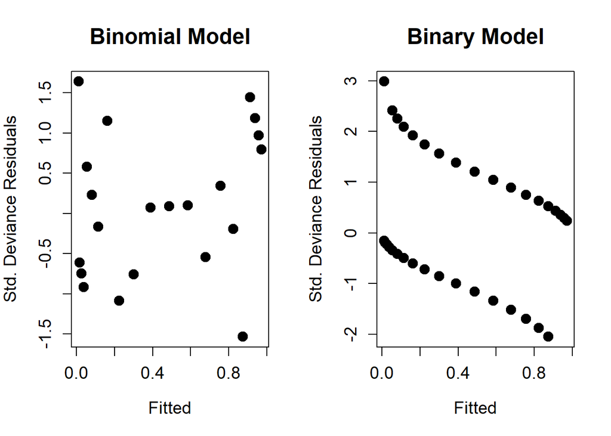

The residual deviance is also different. In fact, there is more residual deviance on the binary compared to the binomial model. However, comparing two binary and binomial models actually leads to the same conclusion. In other terms the deviance seems to be on a different scale[^9]:

```r
fit0_binary <- update(fit_binary, . ~ -x) # null binary model
fit0_binomial <- update(fit_binomial, . ~ -x) # null binary model
```

In fact, if we compare the full model with the null model in both binary and binomial version, the LRT is the same but the deviance is on a different scale. Comparing a binary with a binomial model could be completely misleading.

```r
anova(fit_binomial, fit0_binomial, test = "Chisq")
## Analysis of Deviance Table
##
## Model 1: nc/nt ~ x
## Model 2: nc/nt ~ 1
##   Resid. Df Resid. Dev Df Deviance  Pr(>Chi)
## 1        19     14.426
## 2        20    147.602 -1  -133.18 < 2.2e-16 ***
## ---
## Signif. codes:  0 '***' 0.001 '**' 0.01 '*' 0.05 '.' 0.1 ' ' 1
anova(fit_binary, fit0_binary, test = "Chisq")
## Analysis of Deviance Table
##
## Model 1: y ~ x
## Model 2: y ~ 1
##   Resid. Df Resid. Dev Df Deviance  Pr(>Chi)
## 1       208     155.64
## 2       209     288.81 -1  -133.18 < 2.2e-16 ***
## ---
## Signif. codes:  0 '***' 0.001 '**' 0.01 '*' 0.05 '.' 0.1 ' ' 1
```

## Binomial vs Binary: type of predictors

This point is less relevant in this course but important in general. Usually, **binary regression** is used when the predictor is at the *trial level* whereas **binomial regression** is used when the predictor is at the *participant level*. When both levels are of interests one should use a mixed-effects model where both levels can be modeled.

- the probability of correct responses during an exam as a function of the question difficulty (each trial/row could have a different $x$ level)
- the probability of passing the exam as a function of the high-school background regardless of having multiple trials, each trial/row has the same $x_i$ for the participant $i$

> The probability of correct responses during an exam as a function of the question difficulty
- each question (i.e., *trial*) has a 0/1 response and a difficulty level
- we are modelling a single participant, otherwise we need a multilevel (mixed-effects) model

```r
dat <- expand_grid(id = 1, question = 1:30)
dat$y <- rbinom(nrow(dat), 1, 0.7)
dat$difficulty <- sample(1:5, nrow(dat), replace = TRUE)

dat |>
    select(id, question, difficulty, y) |>
    filor::trim_df()
```

```
##    id question difficulty   y
## 1   1        1          1   1
## 2   1        2          3   1
## 3   1        3          3   1
## 4   1        4          1   0
## 5 ...      ...        ... ...
## 6   1       27          1   1
## 7   1       28          5   1
## 8   1       29          1   0
## 9   1       30          1   1
```

> the probability of passing the exam as a function of the high-school background
- each “background” has different students that passed or not the exam (0/1)

```
##   background nc nf nt
## 1       math 20 10 30
## 2  chemistry 16  4 20
## 3        art  4  6 10
## 4      sport 15  5 20
```

Or the binary version:

```
##     y background  nc  nf  nt
## 1   1       math  20  10  30
## 2   1       math  20  10  30
## 3   1       math  20  10  30
## 4   1       math  20  10  30
## 5 ...        ... ... ... ...
## 6   0      sport  15   5  20
## 7   0      sport  15   5  20
## 8   0      sport  15   5  20
## 9   0      sport  15   5  20
```

- To note that despite we can convert between the binary/binomial, the two models are not always the same. The *high-school background example* can be easily modelled either with a binary or binomial model because the predictor is at the participant level that coincides with the trial level.
- On the other side, the *question difficulty example* can only be modelled using a binary regression because each trial (0/1) has a different value for the predictor
- To include both predictors or to model multiple participants on the *question difficulty example* we need a mixed-effects model where both levels together with the repeated-measures can be handled.
- a very clear overview of this topic can be found here https://www.rensvandeschoot.com/tutorials/generalised-linear-models-with-glm-and-lme4/

# Probit link

## Probit link

- The mostly used *link function* when using a binomial GLM is the **logit link**. The **probit** link is another *link function* that can be used. The overall approach is the same between **logit** and **probit** models. The only difference is the parameter interpretation (i.e., no odds ratios) and the specific link function (and the inverse) to use.
- The **probit** model use the **cumulative normal distribution** but the actual difference with a **logit** functions is neglegible.

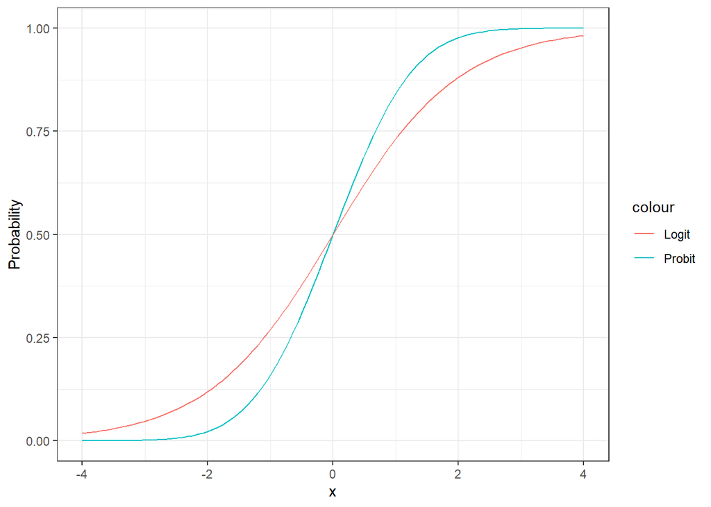

When using the **probit link** the parameters are interpreted as difference in *z-scores* associated with a unit increase in the predictors. In fact probabilities are mapped into *z-scores* using the cumulative normal distribution.

```r
p1 <- 0.7
p2 <- 0.5

qlogis(c(p1, p2)) # log(odds(p1)), logit link
```

```
## [1] 0.8472979 0.0000000
```

```r
qnorm(c(p1, p2)) # probit link
```

```
## [1] 0.5244005 0.0000000
```

```r
log(odds_ratio(p1, p2)) # ~ beta1, logit link
```

```
## [1] 0.8472979
```

```r
pnorm(p1) - pnorm(p2) # ~beta1, probit link
```

```
## [1] 0.06657389
```

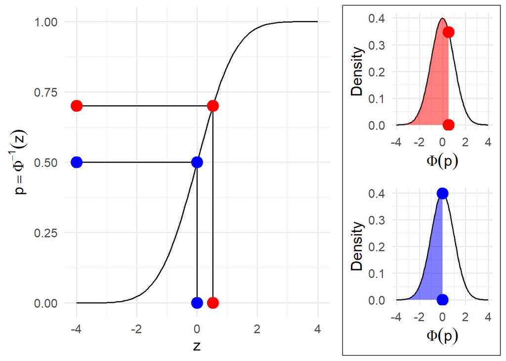

# References

Agresti, A. (2015). *Foundations of linear and generalized linear models*. John Wiley & Sons. https://play.google.com/store/books/details?id=jlIqBgAAQBAJ

Arel-Bundock, V., Greifer, N., & Heiss, A. (2024). How to interpret statistical models using marginaleffects for *r* and *python*. *Journal of Statistical Software*, *111*, 1–32. https://doi.org/10.18637/jss.v111.i09

Borenstein, M., Hedges, L. V., Higgins, J. P. T., & Rothstein, H. R. (2009). *Introduction to Meta-Analysis*. https://doi.org/10.1002/9780470743386

Dunn, P. K., & Smyth, G. K. (1996). Randomized quantile residuals. *Journal of Computational and Graphical Statistics: A Joint Publication of American Statistical Association, Institute of Mathematical Statistics, Interface Foundation of North America*, *5*, 236–244. https://doi.org/10.1080/10618600.1996.10474708

Dunn, P. K., & Smyth, G. K. (2018). *Generalized linear models with examples in r*. Springer. https://play.google.com/store/books/details?id=tBh5DwAAQBAJ

Gelman, A., & Hill, J. (2006). *Data analysis using regression and multilevel/hierarchical models*. Cambridge University Press. https://doi.org/10.1017/CBO9780511790942

Gelman, A., Hill, J., & Vehtari, A. (2020). *Regression and other stories*. Cambridge University Press. https://doi.org/10.1017/9781139161879

Knoblauch, K., & Maloney, L. T. (2012). *Modeling psychophysical data in r*. Springer New York. https://doi.org/10.1007/978-1-4614-4475-6

McFadden, D. (1987). Regression-based specification tests for the multinomial logit model. *Journal of Econometrics*, *34*, 63–82. https://doi.org/10.1016/0304-4076(87)90067-4

Sánchez-Meca, J., Marín-Martínez, F., & Chacón-Moscoso, S. (2003). Effect-size indices for dichotomized outcomes in meta-analysis. *Psychological Methods*, *8*, 448–467. https://doi.org/10.1037/1082-989X.8.4.448

Tjur, T. (2009). Coefficients of determination in logistic regression models—a new proposal: The coefficient of discrimination. *The American Statistician*, *63*, 366–372. https://doi.org/10.1198/tast.2009.08210

[^1]: Thanks to Prof. Paolo Girardi for the example, see https://teddychild.dpss.psy.unipd.it/ for information
[^2]: see also the [`investr`](https://cran.r-project.org/web/packages/investr/vignettes/introduction.pdf) package
[^3]: Adapted from https://bookdown.org/egarpor/SSS2-UC3M/logreg-deviance.html
[^4]: Adapted from Dunn (2018), Fig. 8.1
[^5]: We are using a Poisson model only because the residual pattern is more clear compared to a binomial model
[^6]: Note that you are not required to re-fit the model to estimate the DFBETAs, you can use the $H$ matrix, see https://en.wikipedia.org/wiki/Influential_observation
[^7]: The function actually computes also other influence measures, see Dunn (2018, section 8.8.3) for other details
[^8]: To note, the **binned residuals** could be considered as an attempt to mitigate the binary residuals problem by creating bins of fitted/residual values similarly to fitting a binomial model.
[^9]: Thanks to Prof. Altoè for this suggestion